# Longitudinal Analysis of Sex Differences in 10-Year Serum Cholesterol Trajectories

Author

Obehi Winnifred Ikpea

Published

September 14, 2024

# 1 Introduction

Heart disease has been the leading cause of death in the United States since the early 1920s. It encompasses a range of conditions that affect the heart, including coronary artery disease, arrhythmias, congenital heart defects, diseases of the heart muscle, and heart valve disease. The need to understand this disease led to the creation of the Framingham Heart Study in 1948, given its overwhelming impact from the 1920s to 1945. This long-term cohort study has played a crucial role in understanding the causes of cardiovascular disease and stroke, as well as the risk factors associated with them. A milestone finding in 1961 was the discovery that high blood pressure and high cholesterol levels increase the risk of heart disease, which led to the popularization of the term “risk factor.” This concept paved the way for preventive approaches to the disease, marking a significant shift from the past practice of treating heart disease only after it had already affected health, such as following a heart attack.

The Framingham Heart Study allowed us to attribute heart disease to certain risk factors, such as high cholesterol levels. Cholesterol is a type of lipid found in the body. The serum cholesterol level represents the total amount of cholesterol in the blood, which includes high-density lipoprotein (HDL), low-density lipoprotein (LDL), and triglycerides. This measure is usually calculated by summing the HDL, LDL, and 20% of the triglyceride level present in a blood sample and comparing them to the optimal ranges: **Optimal:** 125–200 mg/dL, **Borderline high:** 200–239 mg/dL, and **High:** 240 mg/dL or more.

Numerous factors, both controllable and uncontrollable, can impact high cholesterol levels. These encompass health conditions such as Type 2 diabetes and obesity, lifestyle choices like smoking, unhealthy eating patterns, and lack of physical activity, as well as uncontrollable factors such as family history, age, and sex. Women tend to have lower LDL levels (considered bad cholesterol) until approximately age 55, while men usually have lower HDL levels (known as good cholesterol) at any age.

## Project Goal

The goal of the project is to investigate sex differences in serum cholesterol level trajectories over a 10-year follow-up period using Framingham Heart Study data. We aim to determine if mean serum cholesterol levels over time differ between males and females, adjusting for baseline age, BMI, and smoking habits.

# 2 Methods

## **Data Description**

The dataset is a subset of the data collected from the Framingham study and contains 11 columns and 2,634 rows, each representing an individual. The 11 columns include:

- Baseline age of participants (age)
- Sex at birth (1 for male, 2 for female)
- Baseline and 10-year follow-up BMI (bmi0, bmi10)
- Number of cigarettes smoked per day at baseline (cigarettes)
- The serum cholesterol levels measured biennially from baseline to 10-year follow-up period (chol0, chol2, chol4, chol6, chol8, chol10)

## Data Preparation

The dataset was tidied and cleaned before analysis to ensure accuracy and completeness. This process involved:

- Converting cholesterol values (chol0-chol10) of -9 to missing (NA) as per study guidelines.
- Removing all rows with missing values.
- Reshaping the data into a long format, with each row representing a repeated measurement for an individual.

The cleaned dataset consists of 10,362 observations and nine variables.

Table: First 6 Rows of Data

| age | sex | bmi0 | bmi10 | cigarettes | id | levels | cholesterol | year |
| --- | --- | --- | --- | --- | --- | --- | --- | --- |
| 45 | Female | 22 | 22 | 0 | 1 | Chol Year 0 | 220 | 0 |
| 45 | Female | 22 | 22 | 0 | 1 | Chol Year 2 | 217 | 2 |
| 45 | Female | 22 | 22 | 0 | 1 | Chol Year 4 | 217 | 4 |
| 45 | Female | 22 | 22 | 0 | 1 | Chol Year 6 | 200 | 6 |
| 45 | Female | 22 | 22 | 0 | 1 | Chol Year 8 | 219 | 8 |
| 45 | Female | 22 | 22 | 0 | 1 | Chol Year 10 | 240 | 10 |

## Exploratory Data Analysis

An exploratory analysis of the longitudinal data was performed to examine changes in serum cholesterol levels over time, comparing males and females. This analysis aimed to identify unusual patterns or observations and explore the correlation between measurements over time. It included creating a summary table of cholesterol values across different time points, and baseline characteristics, generating a stratified spaghetti plot to visualize individual trajectories by sex, producing a plot of means to show average response trajectories by sex, and developing a correlation plot to investigate the relationship between measurements over time, stratified by sex.

## **Statistical Analysis**

The aim of the project was to investigate sex differences in serum cholesterol level trajectory over a 10-year study period, adjusting for baseline age, baseline BMI, and number of cigarettes smoked at baseline. To address the project objective, we proposed a research question:

**Does the growth rate of serum cholesterol level measured biennially differ for male and female participants, adjusting for baseline age, baseline BMI, and the number of cigarettes smoked at baseline?**

To explore this research question, we utilized two approaches for longitudinal data analysis: the linear mixed effects model and generalized estimating equations.

### **Statistical Methods:**

- **Linear Mixed Effects Model**: This model represents the mean as a combination of fixed effects (population characteristics) and random effects (subject-specific effects) to account for between- and within-subject sources of variability, which induces a specific correlation structure for observations in the same cluster. For this project, we utilized variations of the linear mixed effects model:
  - **Random intercept model**: This model allows each subject to have a unique level of response (intercept) that deviates from the population average.
  - **Random intercept and slope model**: This model allows each subject to have a unique response level (intercept) and a unique rate of change over time (slope). This model can be created by either assuming the random effects are uncorrelated or correlated.
- **Generalized Estimating Equations (GEE):** This method involves developing a marginal model that separates the relationship between the response and the covariates from the correlation between observations in the same cluster. The correlation between successive measurements is modeled explicitly by specifying a working correlation matrix.

### Model Specifications:

- **Marginal Mean Model for GEE and Linear Mixed Effects Models**

$E[Cholesterol_{ij}|year_{j},X] = \beta_0 + \beta_1year_{j} + \beta_2I_{sex=Female} + \beta_3year_{j}*I_{sex=Female} + \beta_4age_{i0} + \beta_5bmi_{i0} + \beta_6cigarettes_{i0}$

### **Statistical Analysis Phases:**

**Linear Mixed-Effects Models:**

- We fitted the linear mixed-effects models and chose the better-fitting model using model fit statistics such as the Akaike Information Criterion (AIC) and the Schwarz Bayesian Information Criterion (BIC).
- After selecting the best-fitting model, we tested the null hypothesis using the likelihood ratio test: $(H_0: \beta_3 = 0)$, which suggests no difference in the biennial rate of change in the expected serum cholesterol level between females and males after adjusting for baseline age, BMI, and number of cigarettes.

**Generalized Estimating Equations:**

- We fitted marginal models with different specifications of the working correlation matrix to account for within-subject correlation for observations in the same cluster and selected the proper working correlation structure using the Correlation Information Criterion (CIC).
- Using the model selected from the Correlation Information Criterion (CIC), we tested the null hypothesis: $(H_0: \beta_3 = 0)$, which suggests no difference in the biennial rate of change in the expected serum cholesterol level between females and males after adjusting for baseline age, BMI, and number of cigarettes.
- Because of the semi-parametric methodology of the GEE approach and the absence of a likelihood function, we employed Wald statistics for hypothesis testing.

# 3 Results

## Exploratory Data Analysis

### Summary Statistics of Cholesterol by Year

Cholesterol Summary Statistics by Year (mg/dL)

| Year | variable | Count | Cholesterol Statistics Mean | Cholesterol Statistics SD |
| --- | --- | --- | --- | --- |
| 0 | cholesterol | 1727 | 219.9 | 44.7 |
| 2 | cholesterol | 1727 | 225.2 | 43.4 |
| 4 | cholesterol | 1727 | 228.4 | 44.2 |
| 6 | cholesterol | 1727 | 238.9 | 44.0 |
| 8 | cholesterol | 1727 | 240.4 | 46.0 |
| 10 | cholesterol | 1727 | 249.4 | 44.3 |

### Baseline Characteristics Summary

**Table 2. Baseline Characteristics Summary Statistics

| **Variable** | **N = 1,727**<sup>1</sup> |
| --- | --- |
| sex |  |
| Male | 850, 49% 0 |
| Female | 877, 51% 0 |
| age |  |
| Mean,(IQR) | 43,(36, 49) |
| SD | 8 |
| bmi0 |  |
| Mean,(IQR) | 24.9,(22.0, 27.0) |
| SD | 4.3 |
| cigarettes |  |
| Mean,(IQR) | 10,(0, 20) |
| SD | 12 |

<sup>1</sup> n, % N missing

### Data Visualizations

#### Boxplot of Cholesterol Levels over Time by Sex

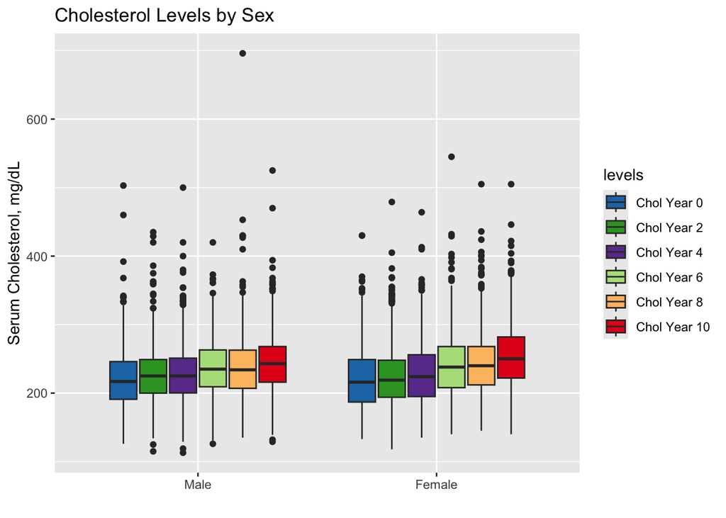

Cholesterol Levels by Sex

#### Correlation of Responses

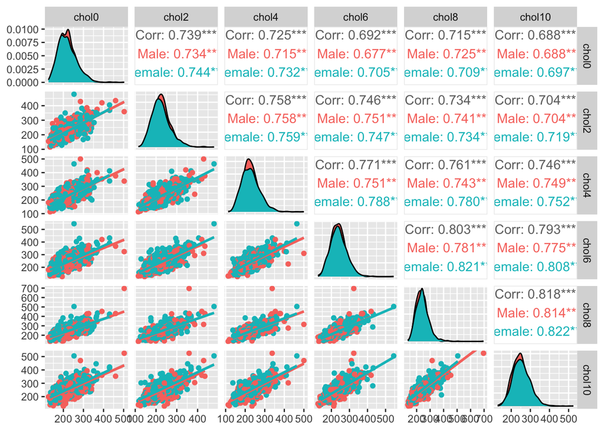

Correlation of Responses by Sex

#### Plot of Means

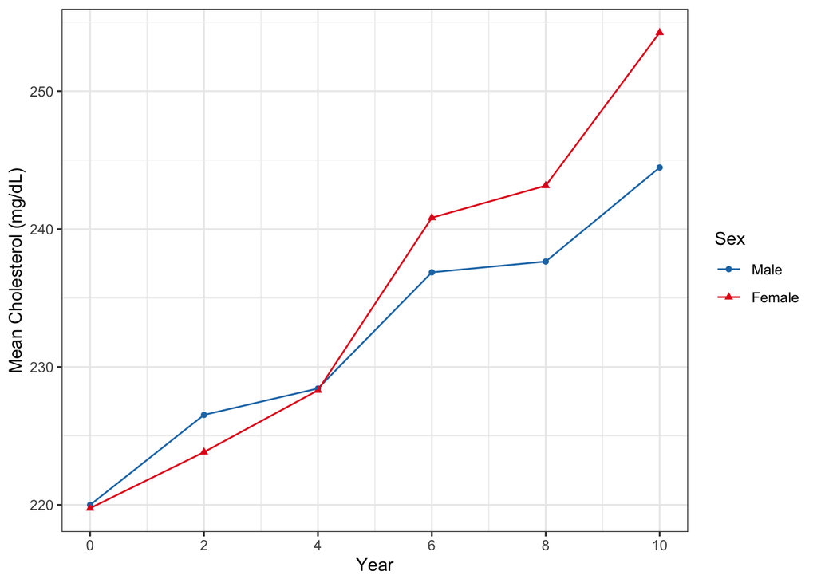

Mean Cholesterol Levels by Sex and Year

#### Spaghetti Plot

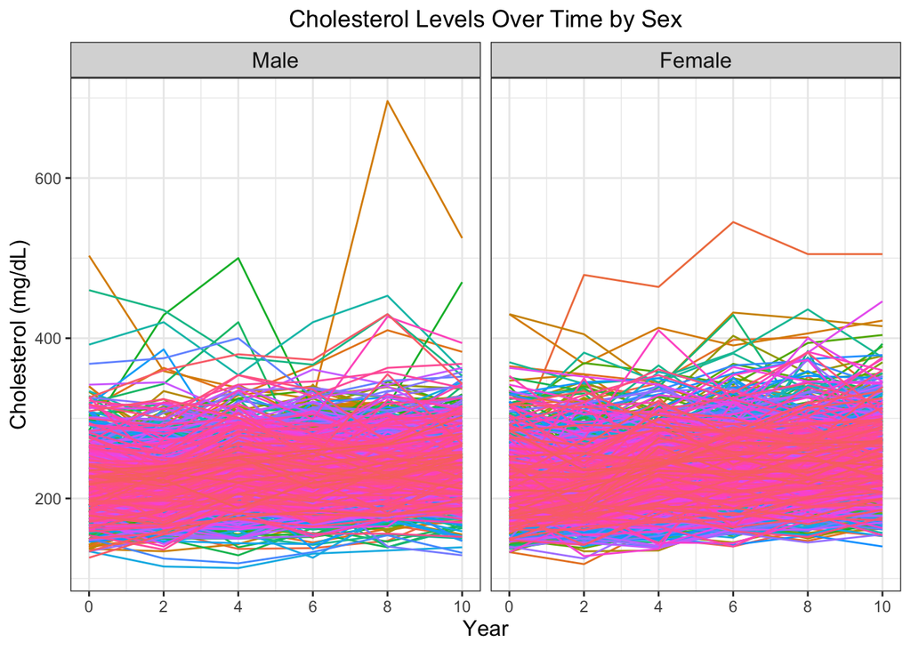

Cholesterol Levels Over Time by Sex

#### Individual Trajectories Over Time

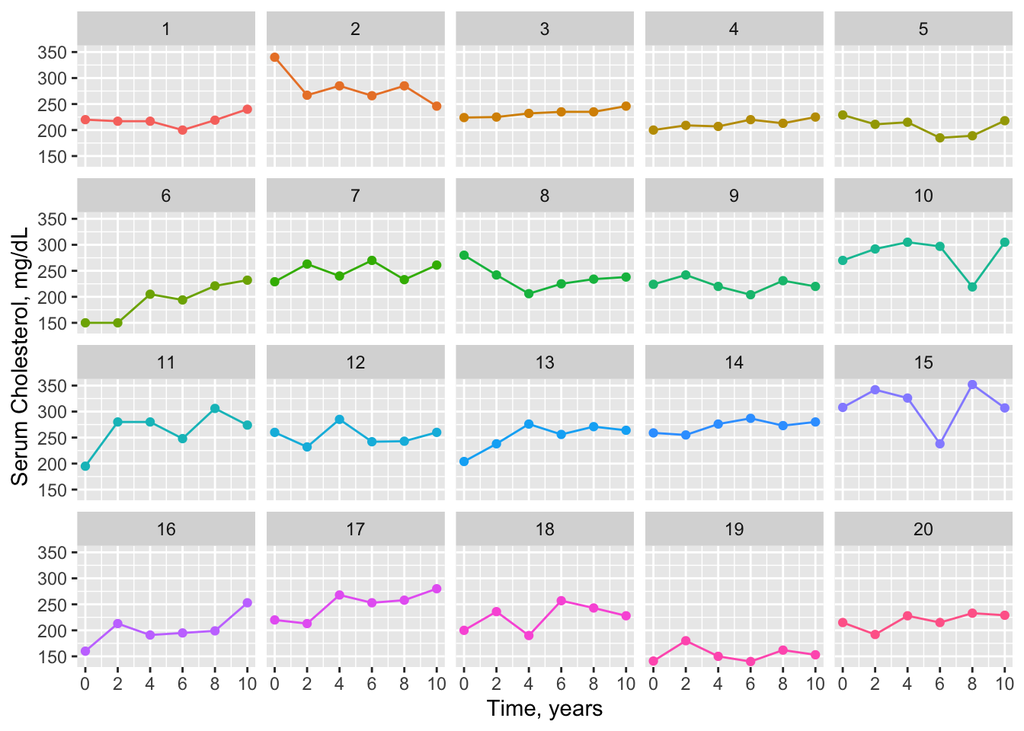

## Statistical Analysis Results

### Linear Mixed Effect Models

#### Model Comparison Using Anova

Model Comparison Using ANOVA

|  | Model | df | AIC | BIC | logLik | Test | L.Ratio | p-value |
| --- | --- | --- | --- | --- | --- | --- | --- | --- |
| model1 | 1 | 9 | 98707.66 | 98772.87 | -49344.83 |  | NA | NA |
| model2 | 2 | 10 | 98513.58 | 98586.04 | -49246.79 | 1 vs 2 | 196.080 | 0.000 |
| model3 | 3 | 11 | 98513.26 | 98592.96 | -49245.63 | 2 vs 3 | 2.327 | 0.127 |

#### Fixed Effects Summary

Fixed Effects Summary

|  | Estimate | Std. Error | DF | t-value | p-value |
| --- | --- | --- | --- | --- | --- |
| (Intercept) | 129.84 | 7.06 | 8633 | 18.40 | 0.00 |
| year | 2.34 | 0.11 | 8633 | 21.52 | 0.00 |
| sexFemale | -0.49 | 2.03 | 1722 | -0.24 | 0.81 |
| age | 1.27 | 0.11 | 1722 | 11.25 | 0.00 |
| bmi0 | 1.29 | 0.21 | 1722 | 6.01 | 0.00 |
| cigarettes | 0.29 | 0.08 | 1722 | 3.48 | 0.00 |
| year:sexFemale | 1.13 | 0.15 | 8633 | 7.36 | 0.00 |

#### Random Effects Summary

```
id = pdDiag(1 + year)
            Variance    StdDev
(Intercept) 1265.183343 35.569416
year           3.689791  1.920883
Residual     447.080140 21.144270
```

#### Hypothesis Testing Result

Hypothesis Testing Using ANOVA

|  | Model | df | AIC | BIC | logLik | Test | L.Ratio | p-value |
| --- | --- | --- | --- | --- | --- | --- | --- | --- |
| model2_reduced | 1 | 9 | 98565.08 | 98630.29 | -49273.54 |  | NA | NA |
| model2 | 2 | 10 | 98513.58 | 98586.04 | -49246.79 | 1 vs 2 | 53.499 | 0 |

### Generalized Estimating Equations

#### Correlation Structure Selection

QIC Values for Different Correlation Structures

|  | QIC | QICu | Quasi Lik | CIC | params | QICC |
| --- | --- | --- | --- | --- | --- | --- |
| mod1 | 19004372 | 19004338 | -9502162 | 23.69671 | 7 | 19004372 |
| mod2 | 18998434 | 18998400 | -9499193 | 23.92618 | 7 | 18998434 |
| mod3 | 18998434 | 18998400 | -9499193 | 23.92618 | 7 | 18998434 |
| mod4 | 19009923 | 19009887 | -9504937 | 24.79376 | 7 | 19009923 |

#### Marginal Model Summary

Generalized Estimating Equation Model: Cholesterol Levels

|  | cholesterol |  |  |
| --- | --- | --- | --- |
| Predictors | Estimates | CI | p |
| (Intercept) | 132.65 | 118.81 – 146.50 | **<0.001** |
| year | 2.29 | 2.09 – 2.50 | **<0.001** |
| sex [Female] | -0.09 | -4.08 – 3.89 | 0.963 |
| age | 1.23 | 1.00 – 1.46 | **<0.001** |
| bmi0 | 1.28 | 0.86 – 1.70 | **<0.001** |
| cigarettes | 0.30 | 0.14 – 0.46 | **<0.001** |
| year × sex [Female] | 1.13 | 0.83 – 1.43 | **<0.001** |
| N <sub>id</sub> | 1727 |  |  |
| Observations | 10362 |  |  |

#### Hypothesis Testing Result

ANOVA Table for GEE Model

|  | Df | X2 | P(>\|Chi\|) |
| --- | --- | --- | --- |
| year | 1 | 1341.480510 | 0.0000000 |
| sex | 1 | 1.254787 | 0.2626401 |
| age | 1 | 130.406641 | 0.0000000 |
| bmi0 | 1 | 31.011530 | 0.0000000 |
| cigarettes | 1 | 13.205569 | 0.0002791 |
| year:sex | 1 | 54.187656 | 0.0000000 |

# 4 Discussion

This project utilized data from the Framingham Heart Study to examine sex differences in serum cholesterol level trajectories over a 10-year follow-up period. Our objective was to determine whether the average serum cholesterol levels over time varied for males and females while accounting for baseline age, BMI, and number of cigarettes smoked. The exploratory data analysis of the longitudinal data revealed several significant findings about trajectories in serum cholesterol levels over time, focusing on comparing males and females. The analysis included summary statistics, visual representations of individual and average trajectories, and correlation assessments, offering valuable insights into the patterns and relationships within the data. The main findings from this analysis are as follows:

- There were 1,727 participants in the study, of whom 51% were females.
- At baseline, the participants’ mean age was 43, their mean BMI was 24.9, and they smoked an average of 10 cigarettes per day.
- The mean serum cholesterol level for the population of participants increased at each measurement time, with an overall 29.5 mg/dL increase from baseline to the 10-year follow-up period.
- There was a positive linear correlation between cholesterol levels measured at different time points, and the correlation measure declined as the time separation increased. However, an interesting trend emerged, showing an increase in the correlation of cholesterol levels between the baseline and year 8 after a consistent decrease for both the general population and males and females.
- The plot of means showed an approximately equal mean serum cholesterol level for males and females at baseline. Then, there was a steady increase for males until year 4, when the means became equal, after which females’ mean level steadily increased.

To investigate the differences, we proposed a research question: **Does the rate of change in mean serum cholesterol level measured biennially differ for male and female participants, adjusting for baseline age, baseline BMI, and the number of cigarettes smoked at baseline?** To explore this question, we utilized two statistical approaches for analyzing longitudinal data: linear mixed effects models and generalized estimating equations.

Both the GEE and LMM approaches produced similar estimates for the fixed effects, supporting the reliability of our findings. The interaction between sex and time was consistent across both models, revealing that females exhibited a greater increase in mean serum cholesterol levels over time compared to males, with both models estimating this difference to be 1.13 mg/dL. The effects of the covariates (baseline age, BMI, and number of cigarettes smoked) were also comparable between the two models, but there were differences in the magnitude of the estimates. This can be attributed to the different assumptions and interpretations of these models; GEE provides population-averaged effects, while LMM accounts for individual-level random effects.

# 5 Appendix

## Linear Mixed Models Result

```
Linear mixed-effects model fit by maximum likelihood
  Data: framingham_longer
       AIC      BIC    logLik
  98513.58 98586.04 -49246.79

Random effects:
 Formula: ~1 + year | id
 Structure: Diagonal
        (Intercept)     year Residual
StdDev:    35.56942 1.920883 21.14427

Fixed effects:  cholesterol ~ year * sex + age + bmi0 + cigarettes
                   Value Std.Error   DF   t-value p-value
(Intercept)    129.84166  7.057768 8633 18.396986  0.0000
year             2.34429  0.108917 8633 21.523612  0.0000
sexFemale       -0.49381  2.026063 1722 -0.243729  0.8075
age              1.27445  0.113237 1722 11.254756  0.0000
bmi0             1.29256  0.214937 1722  6.013648  0.0000
cigarettes       0.29259  0.084023 1722  3.482225  0.0005
year:sexFemale   1.12519  0.152842 8633  7.361789  0.0000
 Correlation:
               (Intr) year   sexFml age    bmi0   cgrtts
year           -0.049
sexFemale      -0.284  0.170
age            -0.573  0.000  0.004
bmi0           -0.667  0.000  0.120 -0.176
cigarettes     -0.370  0.000  0.380  0.172  0.106
year:sexFemale  0.035 -0.713 -0.239  0.000  0.000  0.000

Standardized Within-Group Residuals:
        Min          Q1         Med          Q3         Max
-6.53103762 -0.53069852 -0.01978626  0.50323530 10.51714011

Number of Observations: 10362
Number of Groups: 1727
```

## Generalized Estimating Equations Result

```
Call:
geeglm(formula = cholesterol ~ year * sex + age + bmi0 + cigarettes,
    data = framingham_longer, id = id, corstr = "unstructured")

 Coefficients:
                Estimate   Std.err    Wald Pr(>|W|)
(Intercept)    132.65251   7.06335 352.704  < 2e-16 ***
year             2.29421   0.10549 472.954  < 2e-16 ***
sexFemale       -0.09333   2.03279   0.002 0.963380
age              1.22908   0.11632 111.642  < 2e-16 ***
bmi0             1.27728   0.21429  35.528 2.51e-09 ***
cigarettes       0.30029   0.08264  13.205 0.000279 ***
year:sexFemale   1.12667   0.15305  54.188 1.82e-13 ***
---
Signif. codes:  0 '***' 0.001 '**' 0.01 '*' 0.05 '.' 0.1 ' ' 1

Correlation structure = unstructured
Estimated Scale Parameters:

            Estimate Std.err
(Intercept)     1834   80.76
  Link = identity

Estimated Correlation Parameters:
          Estimate Std.err
alpha.1:2   0.6839 0.02336
alpha.1:3   0.6838 0.02091
alpha.1:4   0.6577 0.02149
alpha.1:5   0.7206 0.03426
alpha.1:6   0.6705 0.02237
alpha.2:3   0.7046 0.02355
alpha.2:4   0.6997 0.02453
alpha.2:5   0.7265 0.02146
alpha.2:6   0.6738 0.02064
alpha.3:4   0.7376 0.02296
alpha.3:5   0.7742 0.01726
alpha.3:6   0.7287 0.02201
alpha.4:5   0.8187 0.02150
alpha.4:6   0.7838 0.02122
alpha.5:6   0.8490 0.02917
Number of clusters:   1727  Maximum cluster size: 6
```

## 6 References

Crippa, A. (2022). *RPubs - A review of Longitudinal Data Analysis in R*. https://rpubs.com/alecri/review_longitudinal

Fitzmaurice, G. M., Laird, N. M., & Ware, J. H. (2011). *Applied longitudinal analysis*. Wiley.

Framingham Heart Study. (2014). *Framingham Heart Study*. https://www.framinghamheartstudy.org/fhs-about/

*GEE for repeated measures analysis | Columbia Public Health*. (n.d.). https://www.publichealth.columbia.edu/research/population-health-methods/repeated-measures-analysis

*Generalized Estimating Equations*. (2023). https://www.ibm.com/docs/en/spss-statistics/saas?topic=statistics-generalized-estimating-equations

Hin, L.-Y., & Wang, Y.-G. (2009). Working-correlation-structure identification in generalized estimating equations. *Statistics in Medicine*, *28*(4), 642–658. https://doi.org/10.1002/sim.3489

Mayo Clinic. (2022). *Heart disease*. https://www.mayoclinic.org/diseases-conditions/heart-disease/symptoms-causes/syc-20353118